# Créez une carte choroplèthe

## Carte de population de Bouira

Une carte choroplèthe (du grec χῶρος : « zone/région » et πλῆθος : « grand nombre, multitude ») est une carte **thématique** où les régions sont *colorées* ou remplies d'un motif qui montre **une mesure statistique**, tels la **densité de population** ou **le revenu par habitant**. Ce type de carte facilite la comparaison d'une mesure statistique d'une région à l'autre ou montre la variabilité de celle-ci pour une région donnée.[wikipedia](https://fr.wikipedia.org/wiki/Carte_choropl%C3%A8the)

### Préparation de données

Nous allos créer une carte **choplèthe** pour visualiser géographiquement la population de Bouira, et pour cela il faut avoir la frontière Administrative de [Bouira](https://nadgy.github.io/4univ/get_Data.html#/3) et aussi télécharger le fichier **CSV** de la [Populations](http://localhost:8000/MyStudentsWork/Population10.csv) de Bouira

*Source du fichier popultion:* [ONS](https://www.ons.dz/collections/)

```python
import geopandas as gpd
import pandas as pd
```

```python
path_to_data ="./data/wbouira.shp"
gdf = gpd.read_file(path_to_data)

gdf
```

|  | ID_0 | ISO | NAME_0 | ID_1 | NAME_1 | ID_2 | NAME_2 | TYPE_2 | ENGTYPE_2 | X | Y | Population | superficie | geometry |
| --- | --- | --- | --- | --- | --- | --- | --- | --- | --- | --- | --- | --- | --- | --- |
| 0 | 5 | DZA | Algeria | 12 | Bouira | 353 | AGHBALOU | Commune | Commune | None | None | None | None | POLYGON ((478679.140 4354598.121, 478546.437 4... |
| 1 | 5 | DZA | Algeria | 12 | Bouira | 354 | AHL-EL-KSAR | Commune | Commune | None | None | None | None | POLYGON ((458096.559 4339404.491, 458085.518 4... |
| 2 | 5 | DZA | Algeria | 12 | Bouira | 355 | AHNIF | Commune | Commune | None | None | None | None | POLYGON ((473835.421 4332764.866, 473715.086 4... |
| 3 | 5 | DZA | Algeria | 12 | Bouira | 356 | AIN-BESSEM | Commune | Commune | None | None | None | None | POLYGON ((410218.793 4335155.776, 410175.479 4... |
| 4 | 5 | DZA | Algeria | 12 | Bouira | 357 | AIN-EL-HADJAR | Commune | Commune | None | None | None | None | POLYGON ((426730.571 4349243.480, 426751.618 4... |
| 5 | 5 | DZA | Algeria | 12 | Bouira | 358 | AIN-LALOUI | Commune | Commune | None | None | None | None | POLYGON ((414504.920 4348625.545, 414544.439 4... |
| 6 | 5 | DZA | Algeria | 12 | Bouira | 359 | AIN-TURK | Commune | Commune | None | None | None | None | POLYGON ((428803.448 4359789.178, 428789.328 4... |
| 7 | 5 | DZA | Algeria | 12 | Bouira | 360 | AIT-LAAZIZ | Commune | Commune | None | None | None | None | POLYGON ((438557.715 4363083.038, 438550.470 4... |
| 8 | 5 | DZA | Algeria | 12 | Bouira | 361 | AOMAR | Commune | Commune | None | None | None | None | POLYGON ((427249.759 4363316.919, 427215.814 4... |
| 9 | 5 | DZA | Algeria | 12 | Bouira | 362 | ATH-MANSOUR | Commune | Commune | None | None | None | None | POLYGON ((476926.874 4347296.472, 476937.331 4... |
| 10 | 5 | DZA | Algeria | 12 | Bouira | 363 | BECHLOUL | Commune | Commune | None | None | None | None | POLYGON ((448654.516 4340431.766, 448587.580 4... |
| 11 | 5 | DZA | Algeria | 12 | Bouira | 364 | BIR-GHBALOU | Commune | Commune | None | None | None | None | POLYGON ((405529.010 4338312.000, 405500.293 4... |
| 12 | 5 | DZA | Algeria | 12 | Bouira | 365 | BORDJ-OKHRISS | Commune | Commune | None | None | None | None | POLYGON ((426167.406 4307012.819, 426155.834 4... |
| 13 | 5 | DZA | Algeria | 12 | Bouira | 366 | BOUDERBALA | Commune | Commune | None | None | None | None | POLYGON ((392844.922 4384172.391, 393300.784 4... |
| 14 | 5 | DZA | Algeria | 12 | Bouira | 367 | BOUIRA | Chef-Lieu-Wilaya | Chef-Lieu-Wilaya | None | None | None | None | POLYGON ((426730.571 4349243.480, 426779.672 4... |
| 15 | 5 | DZA | Algeria | 12 | Bouira | 368 | BOUKRAM | Commune | Commune | None | None | None | None | POLYGON ((367367.903 4376059.806, 367446.384 4... |
| 16 | 5 | DZA | Algeria | 12 | Bouira | 369 | CHORFA | Commune | Commune | None | None | None | None | POLYGON ((482711.458 4348736.265, 482508.635 4... |
| 17 | 5 | DZA | Algeria | 12 | Bouira | 370 | DECHMIA | Commune | Commune | None | None | None | None | POLYGON ((408931.705 4328727.688, 408930.484 4... |
| 18 | 5 | DZA | Algeria | 12 | Bouira | 371 | DIRRAH | Commune | Commune | None | None | None | None | POLYGON ((425063.899 4306334.275, 424907.601 4... |
| 19 | 5 | DZA | Algeria | 12 | Bouira | 372 | DJEBAHIA | Commune | Commune | None | None | None | None | POLYGON ((420478.102 4359749.067, 420458.276 4... |
| 20 | 5 | DZA | Algeria | 12 | Bouira | 373 | EL-ADJIBA | Commune | Commune | None | None | None | None | POLYGON ((460499.867 4340479.707, 460328.679 4... |
| 21 | 5 | DZA | Algeria | 12 | Bouira | 374 | EL-ASNAM | Commune | Commune | None | None | None | None | POLYGON ((448654.516 4340431.766, 448578.928 4... |
| 22 | 5 | DZA | Algeria | 12 | Bouira | 375 | EL-HACHIMIA | Commune | Commune | None | None | None | None | POLYGON ((422183.497 4320581.606, 422180.949 4... |
| 23 | 5 | DZA | Algeria | 12 | Bouira | 376 | EL-HAKIMIA | Commune | Commune | None | None | None | None | POLYGON ((426167.406 4307012.819, 426180.092 4... |
| 24 | 5 | DZA | Algeria | 12 | Bouira | 377 | EL-KHABOUZIA | Commune | Commune | None | None | None | None | POLYGON ((406837.782 4338739.186, 406761.875 4... |
| 25 | 5 | DZA | Algeria | 12 | Bouira | 378 | EL-MOKRANI | Commune | Commune | None | None | None | None | POLYGON ((396860.440 4360082.101, 396878.913 4... |
| 26 | 5 | DZA | Algeria | 12 | Bouira | 379 | GUERROUMA | Commune | Commune | None | None | None | None | POLYGON ((389988.008 4371789.183, 389836.169 4... |
| 27 | 5 | DZA | Algeria | 12 | Bouira | 380 | HADJERA-ZERGA | Commune | Commune | None | None | None | None | POLYGON ((426299.313 4306507.583, 426368.239 4... |
| 28 | 5 | DZA | Algeria | 12 | Bouira | 381 | HAIZER | Commune | Commune | None | None | None | None | POLYGON ((438349.557 4351516.227, 438372.700 4... |
| 29 | 5 | DZA | Algeria | 12 | Bouira | 382 | KADIRIA | Commune | Commune | None | None | None | None | POLYGON ((405093.292 4365529.805, 405058.232 4... |
| 30 | 5 | DZA | Algeria | 12 | Bouira | 383 | LAKHDARIA | Commune | Commune | None | None | None | None | POLYGON ((400237.763 4373757.549, 400226.191 4... |
| 31 | 5 | DZA | Algeria | 12 | Bouira | 384 | M'CHEDALLAH | Commune | Commune | None | None | None | None | POLYGON ((464933.002 4354447.250, 465100.739 4... |
| 32 | 5 | DZA | Algeria | 12 | Bouira | 385 | MAALA | Commune | Commune | None | None | None | None | POLYGON ((397325.432 4361620.207, 397313.277 4... |
| 33 | 5 | DZA | Algeria | 12 | Bouira | 386 | MAAMOURA | Commune | Commune | None | None | None | None | POLYGON ((407438.423 4292686.264, 407420.773 4... |
| 34 | 5 | DZA | Algeria | 12 | Bouira | 387 | MEZDOUR | Commune | Commune | None | None | None | None | POLYGON ((452784.132 4306053.836, 452773.782 4... |
| 35 | 5 | DZA | Algeria | 12 | Bouira | 388 | OUED-EL-BERDI | Commune | Commune | None | None | None | None | POLYGON ((444351.456 4326332.939, 444341.318 4... |
| 36 | 5 | DZA | Algeria | 12 | Bouira | 389 | OULED-RACHED | Commune | Commune | None | None | None | None | POLYGON ((444341.318 4326327.678, 444351.456 4... |
| 37 | 5 | DZA | Algeria | 12 | Bouira | 390 | RAOURAOUA | Commune | Commune | None | None | None | None | POLYGON ((396032.001 4329097.130, 396155.680 4... |
| 38 | 5 | DZA | Algeria | 12 | Bouira | 391 | RIDANE | Commune | Commune | None | None | None | None | POLYGON ((385453.090 4305955.631, 385272.083 4... |
| 39 | 5 | DZA | Algeria | 12 | Bouira | 392 | SAHARIDJ | Commune | Commune | None | None | None | None | POLYGON ((476714.708 4354724.728, 476383.056 4... |
| 40 | 5 | DZA | Algeria | 12 | Bouira | 393 | SOUK-EL-KHEMIS | Commune | Commune | None | None | None | None | POLYGON ((404434.394 4347814.163, 404346.465 4... |
| 41 | 5 | DZA | Algeria | 12 | Bouira | 394 | SOUR-EL-GHOZLANE | Commune | Commune | None | None | None | None | POLYGON ((408931.705 4328727.688, 408964.217 4... |
| 42 | 5 | DZA | Algeria | 12 | Bouira | 395 | TAGHZOUT | Commune | Commune | None | None | None | None | POLYGON ((438557.715 4363083.038, 438838.144 4... |
| 43 | 5 | DZA | Algeria | 12 | Bouira | 396 | TAGUEDITE | Commune | Commune | None | None | None | None | POLYGON ((448194.885 4281452.803, 448058.944 4... |
| 44 | 5 | DZA | Algeria | 12 | Bouira | 397 | Z'BARBAR | Commune | Commune | None | None | None | None | POLYGON ((396860.440 4360082.101, 396647.372 4... |

```python
path_2 ="./data/Population10.csv"
df = pd.read_csv(path_2)

df
```

|  | Commune | Masculin | Féminin | Total | Taux | Commune_ar |
| --- | --- | --- | --- | --- | --- | --- |
| 0 | Bouira | 44950 | 43851 | 88801 | 1.7 | اﻟﺒﻮﻳﺮة |
| 1 | El Asnam | 6615 | 6597 | 13213 | 0.9 | اﻷﺻﻨﺎم |
| 2 | Guerrouma | 7398 | 7172 | 14570 | 0.5 | ﻗﺮوﻣﺔ |
| 3 | Souk El Khemis | 467 | 3935 | 83 | 0.0 | ﺳﻮق-اﻟﺨﻤﻴﺲ |
| 4 | Kadiria | 11268 | 1160 | 22327 | 2.3 | اﻟﻘﺎدرﻳﺔ |
| 5 | ahnif | 4876 | 4810 | 9685 | 0.6 | اﻟﺤﺎﻧﻴﻒ |
| 6 | Dirrah | 6864 | 6346 | 13209 | 0.6 | دﻳﺮة |
| 7 | Ait Laaziz | 7450 | 6980 | 14430 | 0.3 | ﺁﻳﺖ-ﻟﻌﺰﻳﺰ |
| 8 | Taghzout | 6636 | 6567 | 13203 | 1.0 | ﺗﺎﻏﺰوت |
| 9 | Raouraoua | 4278 | 4172 | 8450 | 1.6 | راوراوة |
| 10 | Mezdour | 5567 | 5480 | 1147 | 0.3 | ﻣﺰدور |
| 11 | Haizer | 8937 | 8782 | 17719 | 1.4 | اﻟﺤﻴﺰر |
| 12 | Lakhdaria | 30719 | 2927 | 59746 | 1.3 | اﻷﺧﻀﺮﻳﺔ |
| 13 | Maala | 2650 | 2646 | 5296 | 0.9 | اﻟﻤﻌﻠﻤﺔ |
| 14 | El Hachimia | 8791 | 8530 | 17322 | 2.6 | اﻟﻬﺎﺷﻤﻴﺔ |
| 15 | Aomar | 10508 | 1024 | 20532 | 0.0 | أوﻋﻤﺮ |
| 16 | Chorfa | 8237 | 7936 | 16173 | 0.9 | اﻟﺸﺮﻓﺎء |
| 17 | Bordj Okhriss | 5331 | 5137 | 10467 | 1.6 | ﺑﺮج-أوﺧﺮﻳﺺ |
| 18 | El Adjiba | 6325 | 6162 | 12486 | 0.8 | اﻟﻌﺠﻴﺒﺔ |
| 19 | El Hakimia | 1149 | 163 | 2212 | 0.0 | اﻟﺤﺎآﻤﻴﺔ |
| 20 | El Khabouzia | 391 | 340 | 6132 | 1.0 | اﻟﺨﺒﻮزﻳﺔ |
| 21 | Ahl El Ksar | 6703 | 6651 | 13354 | 0.8 | أهﻞ_اﻟﻘﺼﺮ |
| 22 | Bouderbala | 8846 | 8743 | 17589 | 0.5 | ﺑﻮدرﺑﺎﻟﺔ |
| 23 | Z'barbar | 1850 | 1918 | 3768 | -1.8 | زﺑﺮﺑﺮ |
| 24 | Ain El Hadjar | 4659 | 4601 | 9260 | 1.5 | ﻋﻴﻦ-اﻟﺤﺠﺎر |
| 25 | Djebahia | 7971 | 7622 | 15592 | 0.7 | ﺟﺒﺎﺣﻴﺔ |
| 26 | Aghbalou | 9945 | 9571 | 19517 | 0.0 | أﻏﺒﺎﻟﻮ |
| 27 | Taguedite | 5350 | 5212 | 10562 | 0.3 | ﺗﺎﻗﺪﻳﺖ |
| 28 | Ain Turk | 499 | 3750 | 7849 | 1.4 | ﻋﻴﻦ-اﻟﺘﺮك |
| 29 | Saharidj | 4270 | 4252 | 8522 | 0.7 | اﻟﺼﻬﺎرﻳﺞ |
| 30 | Dechmia | 3802 | 3702 | 7504 | 0.1 | اﻟﺪﺷﻤﻴﺔ |
| 31 | Ridane | 1692 | 1576 | 3268 | 0.8 | رﻳﺪان |
| 32 | Bechloul | 5910 | 5865 | 11775 | 1.3 | ﺑﺸﻠﻮل |
| 33 | Boukram | 2778 | 2868 | 5647 | -1.1 | ﺑﻮآﺮوم |
| 34 | Ain Bessem | 21592 | 2143 | 42635 | 1.5 | ﻋﻴﻦ-ﺑﺴﺎم |
| 35 | Bir Ghbalou | 5646 | 5370 | 1116 | 1.9 | ﺑﺌﺮ-ﻏﺒﺎﻟﻮ |
| 36 | M'chedallah | 12426 | 11981 | 24406 | 1.3 | ﻣﺸﺪااﷲ |
| 37 | Sour El Ghozlane | 25360 | 24760 | 50120 | 1.8 | ﺻﻮر-اﻟﻐﺰﻻن |
| 38 | Maamoura | 1858 | 1794 | 3652 | 0.2 | اﻟﻤﻌﻤﻮرة |
| 39 | Ouled Rached | 4721 | 4590 | 9311 | 0.9 | أوﻻد-راﺷﺪ |
| 40 | Ain Laloui | 3557 | 3182 | 6738 | 1.4 | ﻋﻴﻦ-اﻟﻌﻠﻮى |
| 41 | Hadjera Zerga | 1887 | 1786 | 3672 | 1.4 | اﻟﺤﺠﺮة-اﻟﺰرﻗﺎء |
| 42 | Ath Mansour | 5117 | 4959 | 1077 | 0.8 | ﺁث-ﻣﻨﺼﻮر |
| 43 | El Mokrani | 1942 | 219 | 3961 | -2.1 | اﻟﻤﻘﺮاﻧﻲ |
| 44 | Oued El Berdi | 5510 | 5257 | 10767 | 1.6 | وادى-اﻟﺒﺮدي |

# Normalisation des données

- Mettre les noms de communes en majuscule
- Remplacer le caractère blanc par un tiret '-'
- Renommer la colomnne Communes par NAME_2

```python
df['Commune']=df['Commune'].str.upper()
```

```python
df['Commune']=df['Commune'].str.replace(' ', '-')
```

```python
df.rename(columns={"Commune": "NAME_2"}, inplace=True)
```

- Sauvegarder le dataframe normalisé

```python
df.to_csv('path_2', index=False)
```

# Fusion

Maintenant, après avoir normaliser on peut Fusionner la geodataframe (frontière) avec la dataframe (Population)

*Question* on dit **un** dataframe où **une** dataframe?

```python
merged = pd.merge(left=gdf, right=df, how="left", on="NAME_2")
merged
```

|  | ID_0 | ISO | NAME_0 | ID_1 | NAME_1 | ID_2 | NAME_2 | TYPE_2 | ENGTYPE_2 | X | Y | Population | superficie | geometry | Masculin | Féminin | Total | Taux | Commune_ar |
| --- | --- | --- | --- | --- | --- | --- | --- | --- | --- | --- | --- | --- | --- | --- | --- | --- | --- | --- | --- |
| 0 | 5 | DZA | Algeria | 12 | Bouira | 353 | AGHBALOU | Commune | Commune | None | None | None | None | POLYGON ((478679.140 4354598.121, 478546.437 4... | 9945 | 9571 | 19517 | 0.0 | أﻏﺒﺎﻟﻮ |
| 1 | 5 | DZA | Algeria | 12 | Bouira | 354 | AHL-EL-KSAR | Commune | Commune | None | None | None | None | POLYGON ((458096.559 4339404.491, 458085.518 4... | 6703 | 6651 | 13354 | 0.8 | أهﻞ_اﻟﻘﺼﺮ |
| 2 | 5 | DZA | Algeria | 12 | Bouira | 355 | AHNIF | Commune | Commune | None | None | None | None | POLYGON ((473835.421 4332764.866, 473715.086 4... | 4876 | 4810 | 9685 | 0.6 | اﻟﺤﺎﻧﻴﻒ |
| 3 | 5 | DZA | Algeria | 12 | Bouira | 356 | AIN-BESSEM | Commune | Commune | None | None | None | None | POLYGON ((410218.793 4335155.776, 410175.479 4... | 21592 | 2143 | 42635 | 1.5 | ﻋﻴﻦ-ﺑﺴﺎم |
| 4 | 5 | DZA | Algeria | 12 | Bouira | 357 | AIN-EL-HADJAR | Commune | Commune | None | None | None | None | POLYGON ((426730.571 4349243.480, 426751.618 4... | 4659 | 4601 | 9260 | 1.5 | ﻋﻴﻦ-اﻟﺤﺠﺎر |
| 5 | 5 | DZA | Algeria | 12 | Bouira | 358 | AIN-LALOUI | Commune | Commune | None | None | None | None | POLYGON ((414504.920 4348625.545, 414544.439 4... | 3557 | 3182 | 6738 | 1.4 | ﻋﻴﻦ-اﻟﻌﻠﻮى |
| 6 | 5 | DZA | Algeria | 12 | Bouira | 359 | AIN-TURK | Commune | Commune | None | None | None | None | POLYGON ((428803.448 4359789.178, 428789.328 4... | 499 | 3750 | 7849 | 1.4 | ﻋﻴﻦ-اﻟﺘﺮك |
| 7 | 5 | DZA | Algeria | 12 | Bouira | 360 | AIT-LAAZIZ | Commune | Commune | None | None | None | None | POLYGON ((438557.715 4363083.038, 438550.470 4... | 7450 | 6980 | 14430 | 0.3 | ﺁﻳﺖ-ﻟﻌﺰﻳﺰ |
| 8 | 5 | DZA | Algeria | 12 | Bouira | 361 | AOMAR | Commune | Commune | None | None | None | None | POLYGON ((427249.759 4363316.919, 427215.814 4... | 10508 | 1024 | 20532 | 0.0 | أوﻋﻤﺮ |
| 9 | 5 | DZA | Algeria | 12 | Bouira | 362 | ATH-MANSOUR | Commune | Commune | None | None | None | None | POLYGON ((476926.874 4347296.472, 476937.331 4... | 5117 | 4959 | 1077 | 0.8 | ﺁث-ﻣﻨﺼﻮر |
| 10 | 5 | DZA | Algeria | 12 | Bouira | 363 | BECHLOUL | Commune | Commune | None | None | None | None | POLYGON ((448654.516 4340431.766, 448587.580 4... | 5910 | 5865 | 11775 | 1.3 | ﺑﺸﻠﻮل |
| 11 | 5 | DZA | Algeria | 12 | Bouira | 364 | BIR-GHBALOU | Commune | Commune | None | None | None | None | POLYGON ((405529.010 4338312.000, 405500.293 4... | 5646 | 5370 | 1116 | 1.9 | ﺑﺌﺮ-ﻏﺒﺎﻟﻮ |
| 12 | 5 | DZA | Algeria | 12 | Bouira | 365 | BORDJ-OKHRISS | Commune | Commune | None | None | None | None | POLYGON ((426167.406 4307012.819, 426155.834 4... | 5331 | 5137 | 10467 | 1.6 | ﺑﺮج-أوﺧﺮﻳﺺ |
| 13 | 5 | DZA | Algeria | 12 | Bouira | 366 | BOUDERBALA | Commune | Commune | None | None | None | None | POLYGON ((392844.922 4384172.391, 393300.784 4... | 8846 | 8743 | 17589 | 0.5 | ﺑﻮدرﺑﺎﻟﺔ |
| 14 | 5 | DZA | Algeria | 12 | Bouira | 367 | BOUIRA | Chef-Lieu-Wilaya | Chef-Lieu-Wilaya | None | None | None | None | POLYGON ((426730.571 4349243.480, 426779.672 4... | 44950 | 43851 | 88801 | 1.7 | اﻟﺒﻮﻳﺮة |
| 15 | 5 | DZA | Algeria | 12 | Bouira | 368 | BOUKRAM | Commune | Commune | None | None | None | None | POLYGON ((367367.903 4376059.806, 367446.384 4... | 2778 | 2868 | 5647 | -1.1 | ﺑﻮآﺮوم |
| 16 | 5 | DZA | Algeria | 12 | Bouira | 369 | CHORFA | Commune | Commune | None | None | None | None | POLYGON ((482711.458 4348736.265, 482508.635 4... | 8237 | 7936 | 16173 | 0.9 | اﻟﺸﺮﻓﺎء |
| 17 | 5 | DZA | Algeria | 12 | Bouira | 370 | DECHMIA | Commune | Commune | None | None | None | None | POLYGON ((408931.705 4328727.688, 408930.484 4... | 3802 | 3702 | 7504 | 0.1 | اﻟﺪﺷﻤﻴﺔ |
| 18 | 5 | DZA | Algeria | 12 | Bouira | 371 | DIRRAH | Commune | Commune | None | None | None | None | POLYGON ((425063.899 4306334.275, 424907.601 4... | 6864 | 6346 | 13209 | 0.6 | دﻳﺮة |
| 19 | 5 | DZA | Algeria | 12 | Bouira | 372 | DJEBAHIA | Commune | Commune | None | None | None | None | POLYGON ((420478.102 4359749.067, 420458.276 4... | 7971 | 7622 | 15592 | 0.7 | ﺟﺒﺎﺣﻴﺔ |
| 20 | 5 | DZA | Algeria | 12 | Bouira | 373 | EL-ADJIBA | Commune | Commune | None | None | None | None | POLYGON ((460499.867 4340479.707, 460328.679 4... | 6325 | 6162 | 12486 | 0.8 | اﻟﻌﺠﻴﺒﺔ |
| 21 | 5 | DZA | Algeria | 12 | Bouira | 374 | EL-ASNAM | Commune | Commune | None | None | None | None | POLYGON ((448654.516 4340431.766, 448578.928 4... | 6615 | 6597 | 13213 | 0.9 | اﻷﺻﻨﺎم |
| 22 | 5 | DZA | Algeria | 12 | Bouira | 375 | EL-HACHIMIA | Commune | Commune | None | None | None | None | POLYGON ((422183.497 4320581.606, 422180.949 4... | 8791 | 8530 | 17322 | 2.6 | اﻟﻬﺎﺷﻤﻴﺔ |
| 23 | 5 | DZA | Algeria | 12 | Bouira | 376 | EL-HAKIMIA | Commune | Commune | None | None | None | None | POLYGON ((426167.406 4307012.819, 426180.092 4... | 1149 | 163 | 2212 | 0.0 | اﻟﺤﺎآﻤﻴﺔ |
| 24 | 5 | DZA | Algeria | 12 | Bouira | 377 | EL-KHABOUZIA | Commune | Commune | None | None | None | None | POLYGON ((406837.782 4338739.186, 406761.875 4... | 391 | 340 | 6132 | 1.0 | اﻟﺨﺒﻮزﻳﺔ |
| 25 | 5 | DZA | Algeria | 12 | Bouira | 378 | EL-MOKRANI | Commune | Commune | None | None | None | None | POLYGON ((396860.440 4360082.101, 396878.913 4... | 1942 | 219 | 3961 | -2.1 | اﻟﻤﻘﺮاﻧﻲ |
| 26 | 5 | DZA | Algeria | 12 | Bouira | 379 | GUERROUMA | Commune | Commune | None | None | None | None | POLYGON ((389988.008 4371789.183, 389836.169 4... | 7398 | 7172 | 14570 | 0.5 | ﻗﺮوﻣﺔ |
| 27 | 5 | DZA | Algeria | 12 | Bouira | 380 | HADJERA-ZERGA | Commune | Commune | None | None | None | None | POLYGON ((426299.313 4306507.583, 426368.239 4... | 1887 | 1786 | 3672 | 1.4 | اﻟﺤﺠﺮة-اﻟﺰرﻗﺎء |
| 28 | 5 | DZA | Algeria | 12 | Bouira | 381 | HAIZER | Commune | Commune | None | None | None | None | POLYGON ((438349.557 4351516.227, 438372.700 4... | 8937 | 8782 | 17719 | 1.4 | اﻟﺤﻴﺰر |
| 29 | 5 | DZA | Algeria | 12 | Bouira | 382 | KADIRIA | Commune | Commune | None | None | None | None | POLYGON ((405093.292 4365529.805, 405058.232 4... | 11268 | 1160 | 22327 | 2.3 | اﻟﻘﺎدرﻳﺔ |
| 30 | 5 | DZA | Algeria | 12 | Bouira | 383 | LAKHDARIA | Commune | Commune | None | None | None | None | POLYGON ((400237.763 4373757.549, 400226.191 4... | 30719 | 2927 | 59746 | 1.3 | اﻷﺧﻀﺮﻳﺔ |
| 31 | 5 | DZA | Algeria | 12 | Bouira | 384 | M'CHEDALLAH | Commune | Commune | None | None | None | None | POLYGON ((464933.002 4354447.250, 465100.739 4... | 12426 | 11981 | 24406 | 1.3 | ﻣﺸﺪااﷲ |
| 32 | 5 | DZA | Algeria | 12 | Bouira | 385 | MAALA | Commune | Commune | None | None | None | None | POLYGON ((397325.432 4361620.207, 397313.277 4... | 2650 | 2646 | 5296 | 0.9 | اﻟﻤﻌﻠﻤﺔ |
| 33 | 5 | DZA | Algeria | 12 | Bouira | 386 | MAAMOURA | Commune | Commune | None | None | None | None | POLYGON ((407438.423 4292686.264, 407420.773 4... | 1858 | 1794 | 3652 | 0.2 | اﻟﻤﻌﻤﻮرة |
| 34 | 5 | DZA | Algeria | 12 | Bouira | 387 | MEZDOUR | Commune | Commune | None | None | None | None | POLYGON ((452784.132 4306053.836, 452773.782 4... | 5567 | 5480 | 1147 | 0.3 | ﻣﺰدور |
| 35 | 5 | DZA | Algeria | 12 | Bouira | 388 | OUED-EL-BERDI | Commune | Commune | None | None | None | None | POLYGON ((444351.456 4326332.939, 444341.318 4... | 5510 | 5257 | 10767 | 1.6 | وادى-اﻟﺒﺮدي |
| 36 | 5 | DZA | Algeria | 12 | Bouira | 389 | OULED-RACHED | Commune | Commune | None | None | None | None | POLYGON ((444341.318 4326327.678, 444351.456 4... | 4721 | 4590 | 9311 | 0.9 | أوﻻد-راﺷﺪ |
| 37 | 5 | DZA | Algeria | 12 | Bouira | 390 | RAOURAOUA | Commune | Commune | None | None | None | None | POLYGON ((396032.001 4329097.130, 396155.680 4... | 4278 | 4172 | 8450 | 1.6 | راوراوة |
| 38 | 5 | DZA | Algeria | 12 | Bouira | 391 | RIDANE | Commune | Commune | None | None | None | None | POLYGON ((385453.090 4305955.631, 385272.083 4... | 1692 | 1576 | 3268 | 0.8 | رﻳﺪان |
| 39 | 5 | DZA | Algeria | 12 | Bouira | 392 | SAHARIDJ | Commune | Commune | None | None | None | None | POLYGON ((476714.708 4354724.728, 476383.056 4... | 4270 | 4252 | 8522 | 0.7 | اﻟﺼﻬﺎرﻳﺞ |
| 40 | 5 | DZA | Algeria | 12 | Bouira | 393 | SOUK-EL-KHEMIS | Commune | Commune | None | None | None | None | POLYGON ((404434.394 4347814.163, 404346.465 4... | 467 | 3935 | 83 | 0.0 | ﺳﻮق-اﻟﺨﻤﻴﺲ |
| 41 | 5 | DZA | Algeria | 12 | Bouira | 394 | SOUR-EL-GHOZLANE | Commune | Commune | None | None | None | None | POLYGON ((408931.705 4328727.688, 408964.217 4... | 25360 | 24760 | 50120 | 1.8 | ﺻﻮر-اﻟﻐﺰﻻن |
| 42 | 5 | DZA | Algeria | 12 | Bouira | 395 | TAGHZOUT | Commune | Commune | None | None | None | None | POLYGON ((438557.715 4363083.038, 438838.144 4... | 6636 | 6567 | 13203 | 1.0 | ﺗﺎﻏﺰوت |
| 43 | 5 | DZA | Algeria | 12 | Bouira | 396 | TAGUEDITE | Commune | Commune | None | None | None | None | POLYGON ((448194.885 4281452.803, 448058.944 4... | 5350 | 5212 | 10562 | 0.3 | ﺗﺎﻗﺪﻳﺖ |
| 44 | 5 | DZA | Algeria | 12 | Bouira | 397 | Z'BARBAR | Commune | Commune | None | None | None | None | POLYGON ((396860.440 4360082.101, 396647.372 4... | 1850 | 1918 | 3768 | -1.8 | زﺑﺮﺑﺮ |

# Cartes choroplèthes

GeoPandas facilite la création de cartes Choropleth (cartes où la couleur de chaque forme est basée sur la valeur d'une variable associée). Utilisez simplement la commande plot avec l'argument de colonne défini sur la colonne dont vous souhaitez utiliser les valeurs pour attribuer des couleurs.

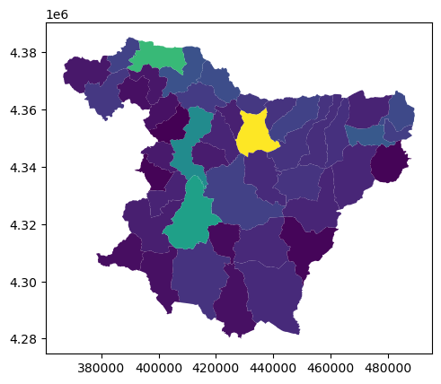

```python
 # Plot by population

merged.plot(column="Total");
```

# Créer une légende

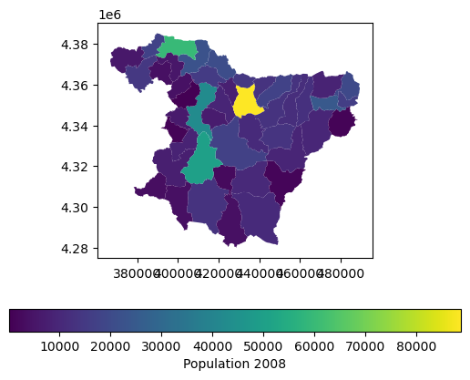

```python
merged.plot(
    column="Total",
    legend=True,
    legend_kwds={"label": "Population 2008", "orientation": "horizontal"},
);
```

Toutefois, l’apparence par défaut des axes de légende et de tracé n’est peut-être pas souhaitable. On peut définir les axes de tracé (avec ax) et les axes de légende (avec cax), puis les transmettre à l'appel plot(). L'exemple suivant utilise mpl_toolkits pour aligner horizontalement les axes du tracé et les axes de la légende et modifier la largeur :

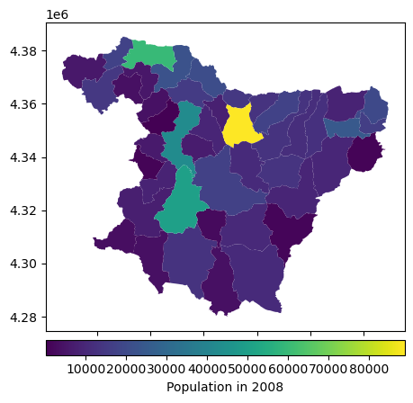

```python
import matplotlib.pyplot as plt

from mpl_toolkits.axes_grid1 import make_axes_locatable

fig, ax = plt.subplots(1, 1)

divider = make_axes_locatable(ax)

cax = divider.append_axes("bottom", size="5%", pad=0.1)

merged.plot(
    column="Total",
    ax=ax,
    legend=True,
    cax=cax,
    legend_kwds={"label": "Population in 2008", "orientation": "horizontal"},
);
```

# Choisir les couleurs

Vous pouvez également modifier les couleurs utilisées par plot() avec l'option cmap. Pour une liste complète des palettes de couleurs, consultez Choisir des palettes de couleurs dans Matplotlib.

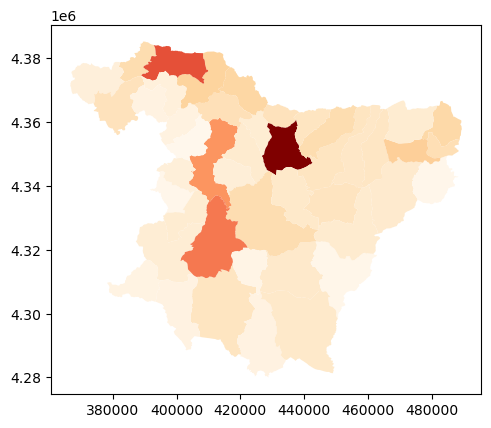

```python
merged.plot(column='Total', cmap='OrRd');
```

# Attention!

Une erreur fréquente lors de la production de cartes choroplèthes consiste à encoder des valeurs de données brutes (comme la population) plutôt que d'utiliser des valeurs normalisées (en calculant la population par kilomètre carré par exemple) pour produire une carte de densité.

# exercice:

Créer une carte de densité selon l'equation suivante:

\begin{equation*} Densité = \frac{Population}{superficie} \end{equation*}

Tout d'abord il faut calculer la colomne [Superficie](https://nadgy.github.io/4univ/geopandas_intro.html) (voir la section: **Zone de mesure** )

```python
merged["Densité"]=merged["Total"]/merged.area
```

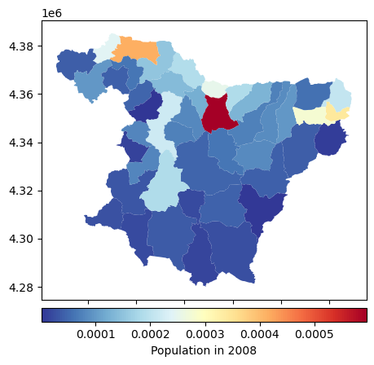

```python
fig, ax = plt.subplots(1, 1)

divider = make_axes_locatable(ax)

cax = divider.append_axes("bottom", size="5%", pad=0.1)

merged.plot(
    column="Densité",
    ax=ax,
    legend=True,
    cax=cax,
    cmap="RdYlBu_r",
    legend_kwds={"label": "Population in 2008", "orientation": "horizontal"},
);
```